# Project BUPRA

Wouter Goossens, Daan Roosen

22-11-2017

## Managementsamenvatting

Om een beter inzicht te krijgen in het facturatieproces van een ziekenhuis, namen wij de dataset ‘Hospital Billing’ onder de loop. We starten onze analyse met het samenvatten van enkele belangrijke elementen uit deze dataset. De dataset (of log) bevat informatie over 451.359 activiteiten die precies 100.000 gevallen (of cases) beschrijven. Deze activiteiten worden uitgevoerd door 1.151 verschillende medewerkers. Er zijn 1.022 verschillende manieren (traces) waarop een geval kan worden doorlopen. De 10 meest voorkomende traces nemen samen 91.3% van de totale log in.

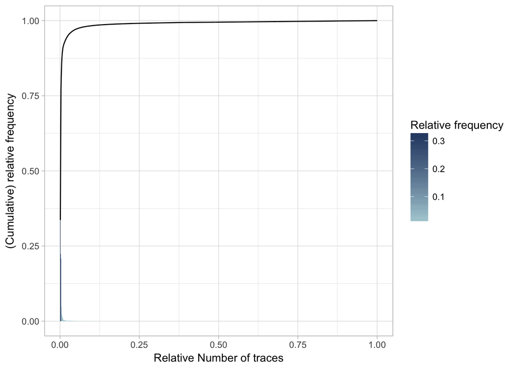

De gemiddelde doorlooptijd bij deze cases is 30 dagen, terwijl de gemiddelde doorlooptijd over de hele log gemiddeld 127 dagen bedraagt.

De log bevat 18 soorten activiteiten waaronder de belangrijkste zijn: - ‘NEW’: het aanmaken van een factuur - ‘FIN’: het afwerken van een factuur - ‘RELEASE’: het uitgeven van een factuur - ‘CODE OK’: de status die wordt gegeven wanneer een factuur wordt goedgekeurd - ‘BILLED’: de status die wordt gegeven wanneer een factuur is betaald - ‘CHANGE DIAGN’: wanneer de diagnose waarvoor de factuur oorspronkelijk werd opgesteld wordt gewijzigd

```
## # A tibble: 18 x 2
##        Activity absolute_frequency
##           <chr>              <int>
##  1          NEW             101289
##  2          FIN              74738
##  3      RELEASE              70926
##  4      CODE OK              68006
##  5       BILLED              67448
##  6 CHANGE DIAGN              45451
##  7       DELETE               8225
##  8       REOPEN               4669
##  9     CODE NOK               3620
## 10       STORNO               2973
## 11       REJECT               2016
## 12   SET STATUS                705
## 13        EMPTY                449
## 14       MANUAL                372
## 15     JOIN-PAT                358
## 16   CODE ERROR                 75
## 17   CHANGE END                 38
## 18   ZDBC_BEHAN                  1
```

## Inleiding

- Case ID: de unieke waarde die aan iedere case wordt toegewezen
- Activity: de naam van de activiteit die werd uitgevoerd
- Resource: de naam van de persoon die deze activiteit heeft uitgevoerd
- Complete Timestamp: het tijdstip waarop de activeit werd afgerond
- Variant: een waarde om aan te duiden wij welk soort trace de case hoort
- Variant index: enkel de numerieke waarde van variant
- actOrange
- actRed
- blocked
- caseType
- closeCode
- diagnosis
- flagA
- flagB
- flagC
- flagD
- isCancelled
- isClosed
- lifecycle:transition
- msgCode
- msgCount
- msgType
- speciality
- state
- version

## Resultaten

1. Hoeveel facturen worden uiteindelijk niet betaald?

```
## # A tibble: 36,502 x 2
##    case_id last_activity
##      <chr>         <chr>
##  1     AAA           NEW
##  2    AAAD           NEW
##  3    AAAE           FIN
##  4     AAB           NEW
##  5    AABB           NEW
##  6    AACE           NEW
##  7     AAD           NEW
##  8    AADA           FIN
##  9    AADE           NEW
## 10    AAEB    SET STATUS
## # ... with 36,492 more rows
```

2. Welke activiteiten moeten vaak opnieuw worden uitgevoerd?

```
##        Activity Frequency
## 1       CODE OK      3447
## 2       RELEASE      3266
## 3           FIN      3072
## 4        BILLED      2150
## 5        REOPEN       454
## 6        STORNO       350
## 7  CHANGE DIAGN       200
## 8      CODE NOK       148
## 9        REJECT       138
## 10       MANUAL        46
## 11   SET STATUS        24
## 12   CODE ERROR         5
## 13   CHANGE END         3
## 14       DELETE         0
## 15        EMPTY         0
## 16     JOIN-PAT         0
## 17          NEW         0
## 18   ZDBC_BEHAN         0
```

```
## # A tibble: 568 x 2
## # Groups:   diagnosis [568]
##    diagnosis frequency
##        <chr>     <int>
##  1        YC       163
##  2       GKA       127
##  3        NE        82
##  4        JA        73
##  5         Z        64
##  6       RKA        54
##  7        KM        51
##  8         L        50
##  9        XG        49
## 10        VF        45
## # ... with 558 more rows
```

8. Welke eerste diagnose was vaak toch de juiste?

```
## # A tibble: 71,885 x 2
##    case_id     n
##      <chr> <int>
##  1       A     1
##  2      AA     1
##  3    AAAA     1
##  4    AAAB     1
##  5    AAAC     1
##  6    AAAE     1
##  7    AABA     1
##  8    AABC     1
##  9    AABD     1
## 10    AABE     1
## # ... with 71,875 more rows
```

9. Welke diagnoses volgen mekaar vaak op?

```
## # A tibble: 1,748 x 3
## # Groups:   previous_diagnosis [568]
##    previous_diagnosis diagnosis frequency
##                 <chr>     <chr>     <int>
##  1                GKA       RKA       109
##  2                 YC        XC        84
##  3                 YC        PE        79
##  4                RKA       GKA        48
##  5                  L        VB        41
##  6                 NE         Z        32
##  7                 ZH        XM        25
##  8                 XG        LC        23
##  9                 NE        DJ        22
## 10                 KM         Q        19
## # ... with 1,738 more rows
```

10. Hoe vaak zijn dokters het niet helemaal eens over de diagnose?

```
## # A tibble: 27,581 x 4
##    case_id     Activity Resource      akkoord
##      <chr>        <chr>    <chr>        <chr>
##  1    AAAA          NEW    ResXG          NEW
##  2    AAAA CHANGE DIAGN    ResJN niet akkoord
##  3    AABD          NEW    ResSD          NEW
##  4    AABD CHANGE DIAGN   ResYAA niet akkoord
##  5    AACA          NEW    ResPP          NEW
##  6    AACA CHANGE DIAGN    ResAI niet akkoord
##  7    AADC          NEW    ResYW          NEW
##  8    AADC CHANGE DIAGN     ResK niet akkoord
##  9    AAEE          NEW    ResJU          NEW
## 10    AAEE CHANGE DIAGN    ResJV niet akkoord
## # ... with 27,571 more rows
```

11. Hoe vaak wordt een eerst afgewezen diagnose, toch opnieuw gesteld?

```
## # A tibble: 359 x 3
## # Groups:   case_id [207]
##    case_id diagnosis abs_freq
##      <chr>     <chr>    <int>
##  1    ABHB        EM        2
##  2    AGHA         N        2
##  3    AGTB        QV        2
##  4    AHLD        DJ        2
##  5    AHLD        NE        2
##  6    AHYC        AL        2
##  7    AOSD         N        2
##  8     APH        AJ       15
##  9     APH        CM        5
## 10     APH        CN        8
## # ... with 349 more rows
```

```
## # A tibble: 114 x 2
##    diagnosis abs_freq
##        <chr>    <int>
##  1         Z       24
##  2        AJ       20
##  3        DJ       17
##  4        MN       13
##  5        NE       13
##  6        CN       12
##  7       RKA       12
##  8        YC       12
##  9        XC       11
## 10        HB       10
## # ... with 104 more rows
```

```
## # A tibble: 1,352 x 2
##    case_id     n
##      <chr> <int>
##  1    AAAB     1
##  2    AACA     1
##  3    AADC     1
##  4     AAE     1
##  5    AALB     1
##  6     ABG     1
##  7    ABKD     1
##  8    ABZA     1
##  9    ACHE     1
## 10    ACLD     1
## # ... with 1,342 more rows
```

12. Hoeveel tijd zit er tussen de goedkeuring en betaling van een factuur?

```
## # A tibble: 1 x 1
##             avg
##          <time>
## 1 48.94975 days
```

# Analyse diagnoses

In de log komen 1191 verschillende diagnoses voor. De diagnoses “PD” en “SB” worden het vaakst gesteld.

```
## # A tibble: 1,191 x 2
##    diagnosis abs_freq
##        <chr>    <int>
##  1        PD     2042
##  2        SB     1952
##  3         Z     1422
##  4         G     1339
##  5        KT     1168
##  6         H     1121
##  7         E     1102
##  8        FA     1094
##  9         X      971
## 10         T      894
## # ... with 1,181 more rows
```

Tijdens het billing proces kan de diagnose van een bepaalde case nog gewijzigd worden. In ongeveer 72 % van de cases is de eerste diagnose de juiste en in 4,29 % van de cases wordt de eerste diagnose één keer gewijzigd. Het blijkt dat de eerste of twee diagnose meestal de juist is aangezien in amper 0,4 % van de gevallen 3 of meer diagnoses nodig zijn. Over iets meer dan 23 % van de cases is geen informatie bekend inzake de diagnoses.

```
## # A tibble: 1 x 1
##       n
##   <int>
## 1 71885
```

```
## # A tibble: 1 x 1
##       n
##   <int>
## 1  4289
```

```
## # A tibble: 1 x 1
##       n
##   <int>
## 1   398
```

We weten nu dat in ongeveer 5 % van de cases de initiële diagnose gewijzigd wordt. Nu kijken we verder naar de diagnoses zelf. Zijn er bijvoorbeeld diagnoses die nadat ze gesteld werden, vaak gewijzigd worden? De onderstaande tabel geeft de diagnoses weer die het vaakst gewijzigd werden op basis van de relative frequentie. Diagnose wordt bijvoorbeeld in 50 % van de gevallen achteraf gewijzigd.

```
## # A tibble: 265 x 4
## # Groups:   diagnosis [265]
##    diagnosis frequency total_number  relative
##        <chr>     <int>        <int>     <dbl>
##  1        KM        51           99 0.5151515
##  2       GKA       127          325 0.3907692
##  3        YO        31           80 0.3875000
##  4         L        50          149 0.3355705
##  5        XH        43          143 0.3006993
##  6        XJ        16           57 0.2807018
##  7        TC        28          120 0.2333333
##  8        JC        20           89 0.2247191
##  9        YC       163          748 0.2179144
## 10        ZH        42          210 0.2000000
## # ... with 255 more rows
```

```
## # A tibble: 71,885 x 2
##    case_id     n
##      <chr> <int>
##  1       A     1
##  2      AA     1
##  3    AAAA     1
##  4    AAAB     1
##  5    AAAC     1
##  6    AAAE     1
##  7    AABA     1
##  8    AABC     1
##  9    AABD     1
## 10    AABE     1
## # ... with 71,875 more rows
```

```
## # A tibble: 5 x 2
##       Activity     n
##          <chr> <int>
## 1 CHANGE DIAGN 45429
## 2       DELETE    22
## 3          FIN   341
## 4       MANUAL     3
## 5          NEW 36026
```

```
## # A tibble: 1 x 1
##       n
##   <int>
## 1 44083
```

```
## # A tibble: 1,162 x 2
##    diagnosis     n
##        <chr> <int>
##  1         A   271
##  2        AA    17
##  3       AAA    12
##  4        AB   128
##  5       ABA     1
##  6        AC   447
##  7       ACA    10
##  8        AD   117
##  9       ADA    15
## 10        AE   224
## # ... with 1,152 more rows
```